# Tutorial

This tutorial walks through a complete weather forecasting workflow with Earth2Studio.jl: fetching initial conditions, running a forecast, and visualizing results.

**Note**

The earth2studio-dependent cells below are shown but not executed during the docs build (they require GPU access and model weights). The plotting cells use synthetic data that mirrors the real output structure so the rendered figures are representative of actual forecast products.

## Setup

```julia
using Earth2Studio
using Dates
```

## Step 1: Fetch Initial Conditions

Choose a data source and fetch fields for a given time and set of variables:

```julia
ds = WB2ERA5()
result = fetch_data(ds, DateTime(2024, 6, 15), ["t2m", "u10m", "v10m"])

result.data    # Array{Float32, 4} with dims (time, variable, lat, lon)
result.dims    # (:time, :variable, :lat, :lon)
result.coords  # NamedTuple with lat/lon vectors, etc.
```

## Step 2: Run a Deterministic Forecast

Load a prognostic model and run a 10-step forecast:

```julia
model = Pangu24()
to_device!(model, "cuda")

io = ZarrBackend("/tmp/forecast.zarr")

result = run_deterministic(DateTime(2024, 6, 15), 10, model, ds, io)
ds_out = to_xarray(result)
```

## Step 3: Visualize the Forecast

### Global Temperature Field

A snapshot of 2-meter temperature at a single forecast lead time. Earth2Studio returns data on a regular latitude-longitude grid.

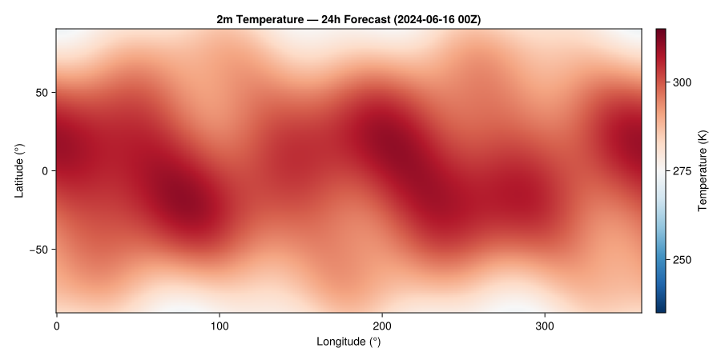

Figure 2.1: 2-meter temperature (K) — 24-hour forecast valid 2024-06-16 00Z

```julia
lat = collect(range(90, -90, length=181))
lon = collect(range(0, 359, length=360))

# Synthetic T2m field: warm tropics, cold poles, land-sea contrast
t2m = [
    280.0 + 25.0 * cosd(la) +
    3.0 * sind(2lo) * cosd(la) +
    5.0 * sind(3la) * cosd(2lo) +
    2.0 * cosd(5lo + 2la)
    for la in lat, lo in lon
]

fig = Figure(size=(900, 450))
ax = Axis(fig[1, 1],
    xlabel="Longitude (°)", ylabel="Latitude (°)",
    title="2m Temperature — 24h Forecast (2024-06-16 00Z)",
)
hm = heatmap!(ax, lon, lat, t2m', colormap=Reverse(:RdBu), colorrange=(235, 315))
Colorbar(fig[1, 2], hm, label="Temperature (K)")
fig
```

### Forecast Time Series

Track a variable at a single grid point across forecast lead times.

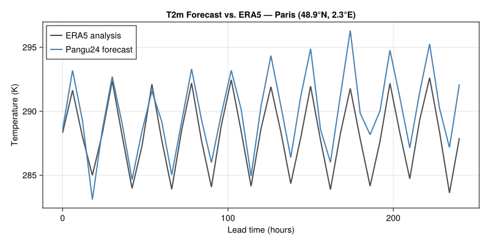

```julia
hours = 0:6:240
n = length(hours)

# Synthetic forecast: diurnal cycle + slight warm drift
t2m_fcst = 288.0 .+ 4.0 .* sin.(2π .* hours ./ 24) .+ 0.015 .* hours .+ 0.8 .* randn(n)

# Synthetic "truth": same diurnal cycle, no drift
t2m_era5 = 288.0 .+ 4.0 .* sin.(2π .* hours ./ 24) .+ 0.5 .* randn(n)

fig = Figure(size=(800, 400))
ax = Axis(fig[1, 1],
    xlabel="Lead time (hours)", ylabel="Temperature (K)",
    title="T2m Forecast vs. ERA5 — Paris (48.9°N, 2.3°E)",
)
lines!(ax, hours, t2m_era5, label="ERA5 analysis", color=:gray30, linewidth=2)
lines!(ax, hours, t2m_fcst, label="Pangu24 forecast", color=:steelblue, linewidth=2)
axislegend(ax, position=:lt)
fig
```

### Ensemble Spread

Run an ensemble forecast to quantify uncertainty:

```julia
io_ens = ZarrBackend("/tmp/ensemble.zarr")
perturb = SphericalGaussian()
result = run_ensemble(DateTime(2024, 6, 15), 40, 10, model, ds, io_ens, perturb)
```

Visualize the ensemble envelope:

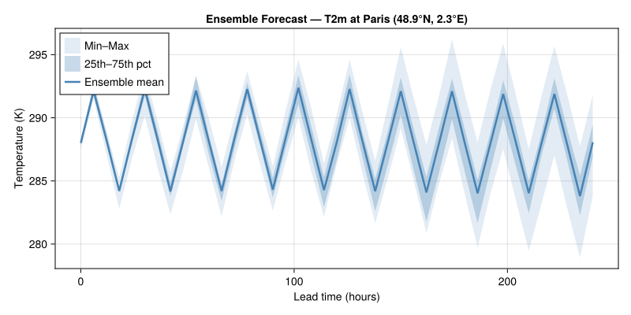

Figure 2.3: 10-member ensemble forecast of T2m showing spread growth with lead time

```julia
hours_ens = 0:6:240
n_ens = length(hours_ens)
n_members = 10

# Synthetic ensemble: members diverge over time
base = 288.0 .+ 4.0 .* sin.(2π .* hours_ens ./ 24)
members = hcat([base .+ cumsum(0.3 .* randn(n_ens)) for _ in 1:n_members]...)

ens_mean = vec(mean(members, dims=2))
ens_min = vec(minimum(members, dims=2))
ens_max = vec(maximum(members, dims=2))
ens_p25 = vec(mapslices(x -> sort(x)[3], members, dims=2))
ens_p75 = vec(mapslices(x -> sort(x)[8], members, dims=2))

fig = Figure(size=(800, 400))
ax = Axis(fig[1, 1],
    xlabel="Lead time (hours)", ylabel="Temperature (K)",
    title="Ensemble Forecast — T2m at Paris (48.9°N, 2.3°E)",
)
band!(ax, hours_ens, ens_min, ens_max, color=(:steelblue, 0.15), label="Min–Max")
band!(ax, hours_ens, ens_p25, ens_p75, color=(:steelblue, 0.3), label="25th–75th pct")
lines!(ax, hours_ens, ens_mean, color=:steelblue, linewidth=2.5, label="Ensemble mean")
axislegend(ax, position=:lt)
fig
```

### Verification: RMSE by Lead Time

Compare forecast skill across models:

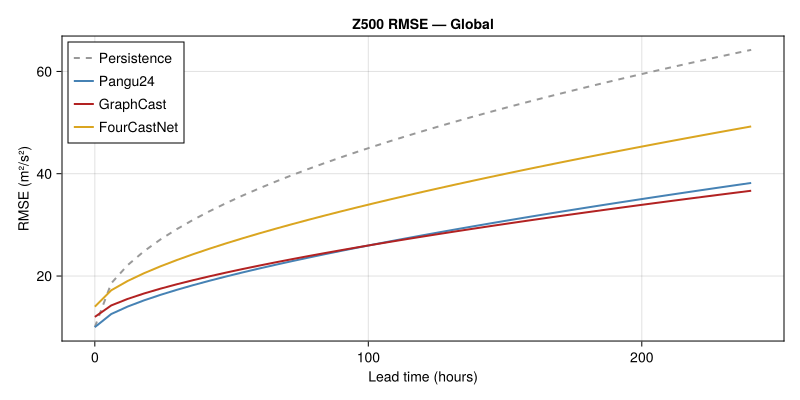

Figure 2.4: Global RMSE of 500 hPa geopotential height by lead time

```julia
hours_v = 0:6:240
n_v = length(hours_v)

# Synthetic RMSE curves: persistence grows fast, AI models grow slowly
rmse_persist = 10.0 .+ 3.5 .* sqrt.(hours_v)
rmse_pangu   = 10.0 .+ 0.8 .* hours_v .^ 0.65
rmse_gcst    = 12.0 .+ 0.7 .* hours_v .^ 0.65
rmse_fcn     = 14.0 .+ 1.0 .* hours_v .^ 0.65

fig = Figure(size=(800, 400))
ax = Axis(fig[1, 1],
    xlabel="Lead time (hours)", ylabel="RMSE (m²/s²)",
    title="Z500 RMSE — Global",
)
lines!(ax, hours_v, rmse_persist, label="Persistence", color=:gray60, linewidth=2, linestyle=:dash)
lines!(ax, hours_v, rmse_pangu, label="Pangu24", color=:steelblue, linewidth=2)
lines!(ax, hours_v, rmse_gcst, label="GraphCast", color=:firebrick, linewidth=2)
lines!(ax, hours_v, rmse_fcn, label="FourCastNet", color=:goldenrod, linewidth=2)
axislegend(ax, position=:lt)
fig
```

## Next Steps

- Swap `WB2ERA5()` for `GFS()` or `ARCO()` to use different initial condition sources.
- Try ensemble methods: `Gaussian()`, `BredVector()`, `LaggedEnsemble()`.
- Add diagnostic models: `run_diagnostic(...)` with `PrecipitationAFNO()` or `CorrDiff()`.
- Compute verification scores: `RMSE()`, `ACC()`, `CRPS()`.